# Chapter 3 Homework

### Web browsing data

For this problem set, we will look at the web browser history for 10k users for 1000 heavily trafficed websites. The data was obtained in the early 2000s. Each browser in the sample spent at least $1 online in the same year.

This is a simple version of the data that are used to build targeted advertising products that predict which customers are most likely to make purchases.

The data are stored in three files.  
* `browser-domains.csv` contains the counts for visits from each user ID to each website ID. * `browser-sites.txt` contains the full names of the domains for each website ID. * `browser-totalspend.csv` contains the total amount spent online that year for each user ID.

Using the code below, you can read the data and convert it into a simple triplet matrix that contains a column for every website, a row for every user, and entries that are 1 if the user visted that website and 0 otherwise.

```r
library(Matrix)

## Browsing History.
## The table has three colums: [machine] id, site [id], [# of] visits
web <- read.csv("browser-domains.csv")
## Read in the actual website names and relabel site factor
sitenames <- scan("browser-sites.txt", what="character")
```

```
Read 1000 items
```

```r
web$site <- factor(web$site, levels=1:length(sitenames), labels=sitenames)
## also factor machine id
web$id <- factor(web$id, levels=1:length(unique(web$id)))


## use this info in a sparse matrix
## this is something you'll be doing a lot; familiarize yourself.
xweb <- sparseMatrix(
    i=as.numeric(web$id), j=as.numeric(web$site),
# replace this with x=web$visits to have a matrix of counts instead of binary 0/1
    x=rep(1,nrow(web)),
    dims=c(nlevels(web$id),nlevels(web$site)),
    dimnames=list(id=levels(web$id), site=levels(web$site)))


# what sites did household 1 visit?
head(xweb[1, xweb[1,]!=0])
```

```
         atdmt.com          yahoo.com
                 1                  1
           msn.com         google.com
                 1                  1
           aol.com questionmarket.com
                 1                  1
```

```r
## now read in the spending data
yspend <- read.csv("browser-totalspend.csv", row.names=1)  # us 1st column as row names
yspend <- as.matrix(yspend) ## good practice to move from dataframe to matrix
```

We now have `yspend` as the user’s total spending and `xweb` as the their browser history.

**Fit a log-linear regression model for `yspend` using a sequence of lasso penalties and produce a path plot. What is the first website to enter the model with a nonzero coefficient?**

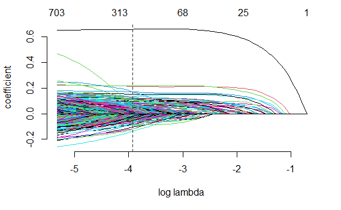

```r
library(gamlr)
spender <- gamlr(xweb, log(yspend))
plot(spender) ## path plot
```

```r
which(spender$beta[,2]!=0)
```

```
bizrate.com-o01
            896
```

Bizrate was an online shopping deal comparison website popular in the early 2000s.

**Use the AIC to select the optimal lasso penalty. What is the optimal lambda value and how many regression coefficients have nonzero estimates at this value? Which 5 websites have the largest positive and negative effects on expected spending?**

First, `spender` has attribute `lambda` and we can use the `AICc` function to get the optimal value.

```r
names(spender)
```

```
 [1] "lambda"   "gamma"    "nobs"     "family"
 [5] "alpha"    "beta"     "df"       "deviance"
 [9] "iter"     "free"     "call"
```

```r
spender$lambda[which.min(AICc(spender))]
```

```
     seg70
0.01981199
```

Since AICc selection is the default, we can just call `coef` to get the coefficients. We do that here and remove the intercept.

```r
beta <- coef(spender)[-1,]
# number nonzero
sum(beta!=0)
```

```
[1] 229
```

```r
# most negative and positive
sort(beta)[1:5]
```

```
               88.80.5.21                032439.com
              -0.13800048               -0.12057711
               alltel.net          srch-results.com
              -0.11667797               -0.10590547
premiumproductsonline.com
              -0.08982103
```

```r
sort(beta, decreasing=TRUE)[1:5]
```

```
          bizrate.com-o01            travelhook.net
                0.6583812                 0.2154362
                  ups.com commerceonlinebanking.com
                0.2138962                 0.1720883
                fedex.com
                0.1702358
```

**What is the predicted annual spending for someone whose browser history includes only google.com and fedex.com?**

You can build an input vector and use the `predict` function, or simply pull out the relevant coefficients (and intercept)

```r
beta[c("fedex.com","google.com")]
```

```
 fedex.com google.com
 0.1702358  0.0000000
```

```r
( logspend <- coef(spender)[1] + sum(beta[c("fedex.com","google.com")]) )
```

```
[1] 5.251569
```

```r
exp(logspend)
```

```
[1] 190.8655
```

**Compare your AICc selected model fit to the results from AIC and BIC selection.**

```r
ll <- log(spender$lambda) ## the sequence of lambdas
plot(spender, col="gray")
abline(v=ll[which.min(AICc(spender))], col="black", lty=2)
```

```r
abline(v=ll[which.min(AIC(spender))], col="orange", lty=2)
abline(v=ll[which.min(BIC(spender))], col="green", lty=2)
```

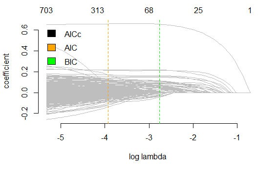

```r
legend("topleft", bty="n",
    fill=c("black","orange","green"),legend=c("AICc","AIC","BIC"))
```

```r
bBIC <- coef(spender, select=which.min(BIC(spender)))[-1,] ## and BIC instead
sum(bBIC!=0)
```

```
[1] 53
```

**Run a CV experiment and use the CV-min rule to select the optimal lambda. What is the out-of-sample R2 at your selected model, and how does it compare to the out-of-sample R2 for the AICc selected model?**

First, just fit the `cv.gamlr` model.

```r
cv.spender <- cv.gamlr(xweb, log(yspend), verb=TRUE)
```

```
fold 1,2,3,4,5,done.
```

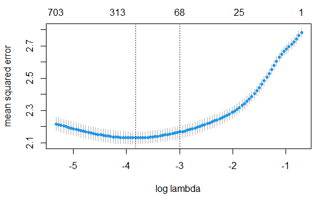

```r
plot(cv.spender)
```

Now look at the the selected lambda (from visual inspection it is similar to the lambda selected by AICc), and calculate the R2s.

```r
cv.spender$lambda.min
```

```
[1] 0.02174364
```

```r
## the R2 at CV-min
1 - cv.spender$cvm[cv.spender$seg.min]/cv.spender$cvm[1]
```

```
[1] 0.2336894
```

```r
## the R2 at AICc selection
1 - cv.spender$cvm[which.min(AICc(spender))]/cv.spender$cvm[1]
```

```
[1] 0.2335432
```

**Build a model for the probability that a user spends more than $1000 in a single year. What is the increase on the odds of spending more than $1000 due to a user having fedex.com in their browser history?**

You can use either CV or AICc selection. Here we will use the AICc selection on a logistic regression lasso fit.

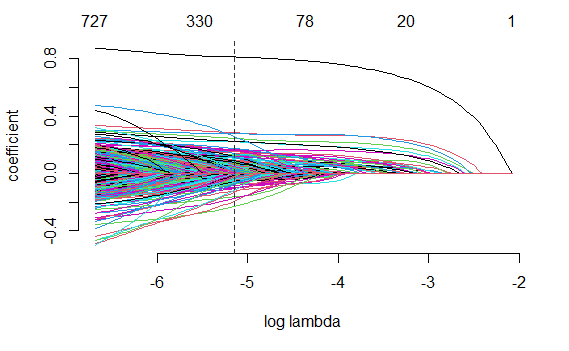

```r
bigspend <- gamlr(xweb, yspend>1000, famil="binomial")
plot(bigspend)
```

```r
blogit <- coef(bigspend)[-1,]
which.max(blogit)
```

```
bizrate.com-o01
            896
```

```r
exp(blogit["fedex.com"])
```

```
fedex.com
 1.276706
```

The odds increas by around 28%.